# Introduction to Neural Networks: Bank Churn prediction

### Model Building: Neural Network model with Adam Optimizer

```python
backend.clear_session()
#Fixing the seed for random number generators so that we can ensure we receive the same output everytime
np.random.seed(2)
random.seed(2)
tf.random.set_seed(2)
```

```python
def create_model(x_train):
    ## Initializing the neural network
    model = Sequential()

    # Input layer with 64 neurons and relu as activation function
    model.add(Dense(units=64,activation='relu',input_dim = x_train.shape[1]))

    # First hidden layer with 32 neurons with relu as activation functions
    model.add(Dense(units=32,activation='relu'))

    # Output layer with Sigmoid Activation
    model.add(Dense(1, activation = 'sigmoid'))

    # Initialize the model with Adam Optimer
    optimizer = tf.keras.optimizers.Adam(lr=1e-3)

    # Compile the model with binary cross entropy as loss function and accuracy as metrics
    model.compile(loss='binary_crossentropy', optimizer=optimizer, metrics=['accuracy'])
    return model
```

```python
model_adam=create_model(x_train)
model_adam.summary()
```

```
WARNING:absl:`lr` is deprecated in Keras optimizer, please use `learning_rate` or use the legacy optimizer, e.g.,tf.keras.optimizers.legacy.Adam.
```

```
Model: "sequential"
_________________________________________________________________
 Layer (type)                Output Shape              Param #
=================================================================
 dense (Dense)               (None, 64)                768

 dense_1 (Dense)             (None, 32)                2080

 dense_2 (Dense)             (None, 1)                 33

=================================================================
Total params: 2881 (11.25 KB)
Trainable params: 2881 (11.25 KB)
Non-trainable params: 0 (0.00 Byte)
_________________________________________________________________
```

```python
adam_history = model_adam.fit(x_train,y_train, batch_size=32, validation_data=(x_val,y_val), epochs=100, verbose=1)
```

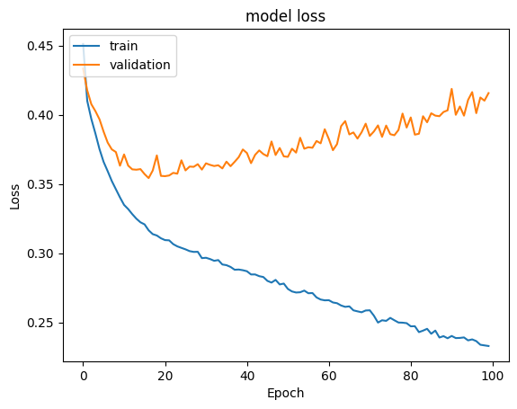

```python
#Plotting Train Loss vs Validation Loss
plt.plot(adam_history.history['loss'])
plt.plot(adam_history.history['val_loss'])
plt.title('model loss')
plt.ylabel('Loss')
plt.xlabel('Epoch')
plt.legend(['train', 'validation'], loc='upper left')
plt.show()
```

We can correct this with early stopping.

```python
# Defining Early stopping
es_cb = callbacks.EarlyStopping(monitor='val_loss', min_delta=0.001, patience=10)

model_adam_e=create_model(x_train)

# Train the model on X_train and y_train for 100 epochs and also use X_val and y_val as validation_data
adam_history_e = model_adam_e.fit(x_train, y_train, batch_size=32, epochs=100, verbose=1, validation_data=(x_val,y_val), callbacks=[es_cb])
```

```
WARNING:absl:`lr` is deprecated in Keras optimizer, please use `learning_rate` or use the legacy optimizer, e.g.,tf.keras.optimizers.legacy.Adam.
```

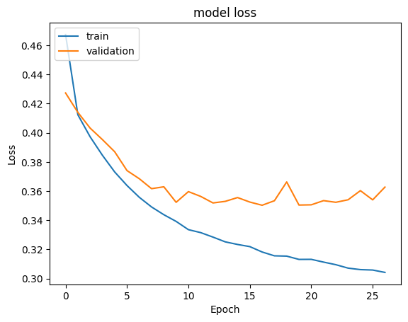

```python
# Plotting Train Loss vs Validation Loss
plt.plot(adam_history_e.history['loss'])
plt.plot(adam_history_e.history['val_loss'])
plt.title('model loss')
plt.ylabel('Loss')
plt.xlabel('Epoch')
plt.legend(['train', 'validation'], loc='upper left')
plt.show()
```

**Let's tune the threshold using ROC-AUC** There are many ways we could locate the threshold with the optimal balance between false positive and true positive rates.

Firstly, the true positive rate is called the Sensitivity. The inverse of the false-positive rate is called the Specificity.

Sensitivity = TruePositive / (TruePositive + FalseNegative)

Specificity = TrueNegative / (FalsePositive + TrueNegative)

Where: Sensitivity = True Positive Rate Specificity = 1 – False Positive Rate The Geometric Mean or G-Mean is a metric for imbalanced classification that, if optimized, will seek a balance between the sensitivity and the specificity.

G-Mean = sqrt(Sensitivity * Specificity)

One approach would be to test the model with each threshold returned from the call roc_auc_score() and select the threshold with the largest G-Mean value.

```
Best Threshold=0.155659, G-Mean=0.814
```

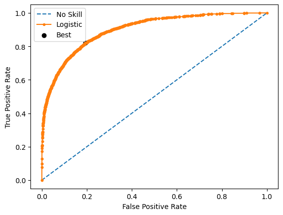

```python
# predict probabilities
yhat = model_adam_e.predict(x_train)
# keep probabilities for the positive outcome only
yhat = yhat[:, 0]
# calculate roc curves
fpr, tpr, thresholds = roc_curve(y_train, yhat)
# calculate the g-mean for each threshold
gmeans = np.sqrt(tpr * (1-fpr))
# locate the index of the largest g-mean
ix = np.argmax(gmeans)
print('Best Threshold=%f, G-Mean=%.3f' % (thresholds[ix], gmeans[ix]))
# plot the roc curve for the model
pyplot.plot([0,1], [0,1], linestyle='--', label='No Skill')
pyplot.plot(fpr, tpr, marker='.', label='Logistic')
pyplot.scatter(fpr[ix], tpr[ix], marker='o', color='black', label='Best')
# axis labels
pyplot.xlabel('False Positive Rate')
pyplot.ylabel('True Positive Rate')
pyplot.legend()
# show the plot
pyplot.show()
```

```python
#Predicting the results using best as a threshold
y_pred_e=model_adam_e.predict(x_val)
y_pred_e = (y_pred_e > thresholds[ix])
y_pred_e
```

```
array([[ True],
       [False],
       [False],
       ...,
       [False],
       [ True],
       [ True]])
```

```python
# Obtain the classification report Hint: use y_val
cr=metrics.classification_report(y_val,y_pred_e)
print(cr)
```

```
              precision    recall  f1-score   support

           0       0.93      0.79      0.85      1274
           1       0.48      0.75      0.59       326

    accuracy                           0.78      1600
   macro avg       0.70      0.77      0.72      1600
weighted avg       0.84      0.78      0.80      1600
```

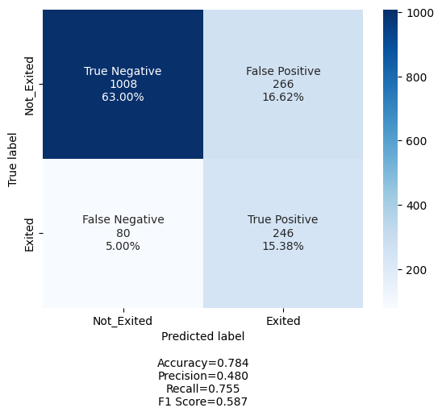

```python
# Confusion Matrix with y_val and y_pred_e to plot the confusion matrix

cm1=confusion_matrix(y_val, y_pred_e)
labels = ['True Negative','False Positive','False Negative','True Positive']
categories = [ 'Not_Exited','Exited']
make_confusion_matrix(cm1,
                      group_names=labels,
                      categories=categories,
                      cmap='Blues')
```

### Model Improvement: Neural Network model with Dropout

```python
backend.clear_session()
#Fixing the seed for random number generators so that we can ensure we receive the same output everytime
np.random.seed(2)
random.seed(2)
tf.random.set_seed(2)
```

```python
def create_model_dropout(x_train):
    #Initializing the neural network
    model = Sequential()

    #Adding the input layer with 32 neurons and relu as activation function
    model.add(Dense(32,activation='relu',input_dim = x_train.shape[1]))

    # Add dropout with dropout_rate= 0.2
    model.add(Dropout(0.2))

    # Adding the first hidden layer with 16 neurons with relu as activation functions
    model.add(Dense(16,activation='relu'))

    # Add dropout with dropout_rate= 0.1
    model.add(Dropout(0.1))

    # Adding the second hidden layer with 8 neurons with relu as activation functions
    model.add(Dense(8,activation='relu'))

    # Adding the output layer
    model.add(Dense(1, activation = 'sigmoid'))

    return model
```

```python
model_dropout = create_model_dropout(x_train)
model_dropout.summary()
```

```
Model: "sequential"
_________________________________________________________________
 Layer (type)                Output Shape              Param #
=================================================================
 dense (Dense)               (None, 32)                384

 dropout (Dropout)           (None, 32)                0

 dense_1 (Dense)             (None, 16)                528

 dropout_1 (Dropout)         (None, 16)                0

 dense_2 (Dense)             (None, 8)                 136

 dense_3 (Dense)             (None, 1)                 9

=================================================================
Total params: 1057 (4.13 KB)
Trainable params: 1057 (4.13 KB)
Non-trainable params: 0 (0.00 Byte)
_________________________________________________________________
```

```python
# Initialize the ANN with Adam optimizer
optimizer = tf.keras.optimizers.Adam(0.001)

# Compile the model with binary cross entropy as loss function and accuracy as metrics
model_dropout.compile(loss='binary_crossentropy', optimizer=optimizer, metrics=['accuracy'])
```

```python
#Fitting the ANN with batch_size = 32 and 100 epochs
dropout_history = model_dropout.fit(x_train,y_train, batch_size=32, epochs=100, verbose=1, validation_data=(x_val,y_val), callbacks=[es_cb])
```

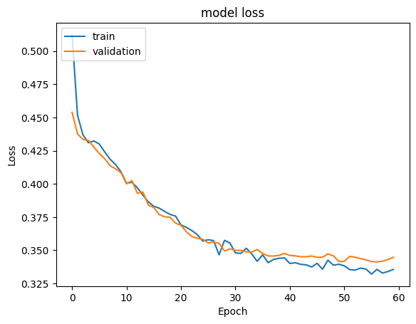

```python
# Plot the Train Loss and Validation Loss
plt.plot(dropout_history.history['loss'])
plt.plot(dropout_history.history['val_loss'])
plt.title('model loss')
plt.ylabel('Loss')
plt.xlabel('Epoch')
plt.legend(['train', 'validation'], loc='upper left')
plt.show()
```

```
Best Threshold=0.179660, G-Mean=0.801
```

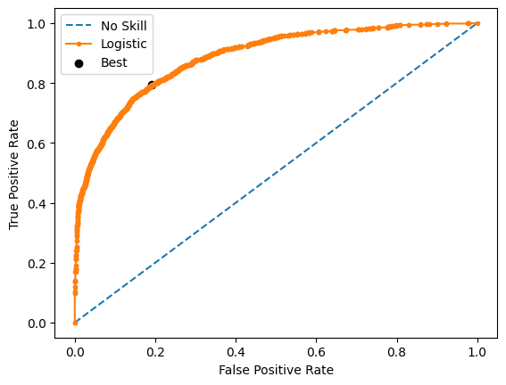

```python
# predict probabilities
yhat = model_dropout.predict(x_train)
# keep probabilities for the positive outcome only
yhat = yhat[:, 0]
# calculate roc curves
fpr, tpr, thresholds = roc_curve(y_train, yhat)
# calculate the g-mean for each threshold
gmeans = np.sqrt(tpr * (1-fpr))
# locate the index of the largest g-mean
ix = np.argmax(gmeans)
print('Best Threshold=%f, G-Mean=%.3f' % (thresholds[ix], gmeans[ix]))
# plot the roc curve for the model
pyplot.plot([0,1], [0,1], linestyle='--', label='No Skill')
pyplot.plot(fpr, tpr, marker='.', label='Logistic')
pyplot.scatter(fpr[ix], tpr[ix], marker='o', color='black', label='Best')
# axis labels
pyplot.xlabel('False Positive Rate')
pyplot.ylabel('True Positive Rate')
pyplot.legend()
# show the plot
pyplot.show()
```

```python
#Predicting the results using best as a threshold
y_pred_e = model_dropout.predict(x_val)
y_pred_dropout_e = (y_pred_e > thresholds[ix])
y_pred_dropout_e
```

```
array([[False],
       [False],
       [False],
       ...,
       [False],
       [ True],
       [ True]])
```

```python
# Obtain the classification report
cr=metrics.classification_report(y_val,y_pred_dropout_e)
print(cr)
```

```
              precision    recall  f1-score   support

           0       0.93      0.80      0.86      1274
           1       0.50      0.76      0.60       326

    accuracy                           0.79      1600
   macro avg       0.71      0.78      0.73      1600
weighted avg       0.84      0.79      0.81      1600
```

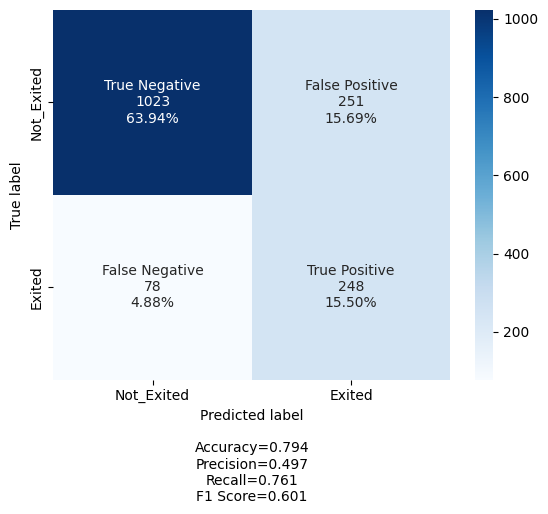

```python
# Confusion Matrix
cm1=confusion_matrix(y_val, y_pred_dropout_e)
labels = ['True Negative','False Positive','False Negative','True Positive']
categories = [ 'Not_Exited','Exited']
make_confusion_matrix(cm1,
                      group_names=labels,
                      categories=categories,
                      cmap='Blues')
```

### Model Improvement: Neural Network model with Hyperparameter tuning

```python
backend.clear_session()
#Fixing the seed for random number generators so that we can ensure we receive the same output everytime
np.random.seed(2)
random.seed(2)
tf.random.set_seed(2)
```

```python
def create_model_hyperparameter(dropout_rate=0.1,lr=0.001,layer_1=64,layer_2=32):
    #Initializing the neural network
    model = Sequential()

    # This adds the input layer (by specifying input dimension)
    model.add(Dense(layer_1, activation='relu', input_dim = x_train.shape[1]))

    # Adding dropout with dropout rate=0.5
    model.add(Dropout(0.5))

    # Adding the hidden layer
    model.add(Dense(layer_2,activation='relu'))

    # Adding the output layer
    # we have an output of 1 node, which is the the desired dimensions of our output (stay with the bank or not)
    # We use the sigmoid because we want probability outcomes
    model.add(Dense(1, activation='sigmoid'))

    # Adding Adam initializer
    optimizer = tf.keras.optimizers.Adam(learning_rate=lr)

    # Compile the model using binary_crossentropy as loss
    model.compile(optimizer = optimizer,loss = 'binary_crossentropy', metrics = ['accuracy'])
    return model
```

```python
# Calling the creat_model_v2 function in KerasClassifier
keras_estimator = KerasClassifier(build_fn=create_model_hyperparameter, verbose=1, lr=0.001)

# define the grid search parameters
param_grid = {
    'batch_size':[40, 64, 128],
    "lr":[0.01,0.001,0.1]}


kfold_splits = 3
# Using the the defined keras_estimator as estimator.
grid = GridSearchCV(estimator=keras_estimator,
                    verbose=1,
                    cv=kfold_splits,
                    param_grid=param_grid,n_jobs=-1)

# Fit the model on train data and use x_val and y_val as validation data
grid_result = grid.fit(x_train, y_train, validation_data = (x_val, y_val),verbose=1)

# Summarize results
print("Best: %f using %s" % (grid_result.best_score_, grid_result.best_params_))
# Printing mean
means = grid_result.cv_results_['mean_test_score']
# Printing standard deviation
stds = grid_result.cv_results_['std_test_score']
# Printing best parameters
params = grid_result.cv_results_['params']
```

```
Fitting 3 folds for each of 9 candidates, totalling 27 fits
Best: 0.815625 using {'batch_size': 40, 'lr': 0.01}
```

```python
# Creating the model
model_hyperparameter = create_model_hyperparameter(lr=grid_result.best_params_['lr'])
# Printing model summary
model_hyperparameter.summary()
```

```
Model: "sequential_1"
_________________________________________________________________
 Layer (type)                Output Shape              Param #
=================================================================
 dense_3 (Dense)             (None, 64)                768

 dropout_1 (Dropout)         (None, 64)                0

 dense_4 (Dense)             (None, 32)                2080

 dense_5 (Dense)             (None, 1)                 33

=================================================================
Total params: 2881 (11.25 KB)
Trainable params: 2881 (11.25 KB)
Non-trainable params: 0 (0.00 Byte)
_________________________________________________________________
```

```python
# Fit the model on train data abd train the model with best batch_size obtained from hyperparameter tuning
history_h=model_hyperparameter.fit(x_train, y_train, epochs=100, batch_size = grid_result.best_params_['batch_size'], verbose=1, validation_data=(x_val,y_val),callbacks=[es_cb])
```

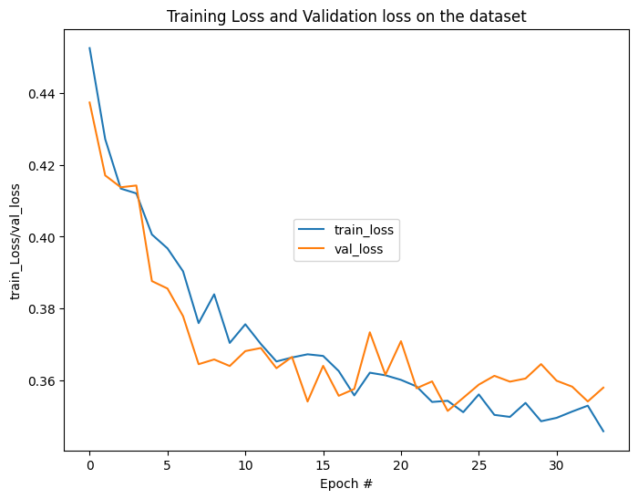

```python
N =history_h.epoch[-1] + 1
plt.figure(figsize=(8,6))
plt.plot(np.arange(0, N), history_h.history["loss"], label="train_loss")
plt.plot(np.arange(0, N), history_h.history["val_loss"], label="val_loss")

plt.title("Training Loss and Validation loss on the dataset")
plt.xlabel("Epoch #")
plt.ylabel("train_Loss/val_loss")
plt.legend(loc="center")
plt.show()
```

```
Best Threshold=0.234769, G-Mean=0.800
```

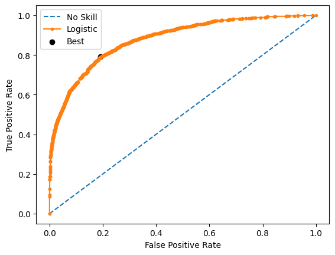

```python
# predict probabilities
yhat = model_hyperparameter.predict(x_train)
# keep probabilities for the positive outcome only
yhat = yhat[:, 0]
# calculate roc curves
fpr, tpr, thresholds = roc_curve(y_train, yhat)
# calculate the g-mean for each threshold
gmeans = np.sqrt(tpr * (1-fpr))
# locate the index of the largest g-mean
ix = np.argmax(gmeans)
print('Best Threshold=%f, G-Mean=%.3f' % (thresholds[ix], gmeans[ix]))
# plot the roc curve for the model
pyplot.plot([0,1], [0,1], linestyle='--', label='No Skill')
pyplot.plot(fpr, tpr, marker='.', label='Logistic')
pyplot.scatter(fpr[ix], tpr[ix], marker='o', color='black', label='Best')
# axis labels
pyplot.xlabel('False Positive Rate')
pyplot.ylabel('True Positive Rate')
pyplot.legend()
# show the plot
pyplot.show()
```

```python
# Obtain the predictions on X_val
y_pred_h = model_hyperparameter.predict(x_val)
print(y_pred_h)
```

```
[[0.22379158]
 [0.00826733]
 [0.04954634]
 ...
 [0.1428217 ]
 [0.5231855 ]
 [0.3968749 ]]
```

```python
# To use the confusion Matrix, we need to convert the probabilities that a customer will leave the bank into the form true or false.
# So we will use the best cutoff value  to indicate whether they are likely to exit or not.
y_pred_h = (y_pred_h > thresholds[ix])
print(y_pred_h)
```

```
[[False]
 [False]
 [False]
 ...
 [False]
 [ True]
 [ True]]
```

```python
# Complete the code to obtain the classification report
cr=metrics.classification_report(y_val,y_pred_h)
print(cr)
```

```
              precision    recall  f1-score   support

           0       0.93      0.79      0.85      1274
           1       0.48      0.76      0.59       326

    accuracy                           0.78      1600
   macro avg       0.70      0.78      0.72      1600
weighted avg       0.84      0.78      0.80      1600
```

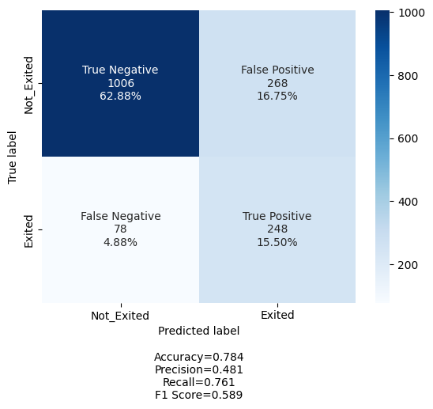

```python
## Complete the code to obtain the confusion matrix
cm_h=confusion_matrix(y_val, y_pred_h)

labels = ['True Negative','False Positive','False Negative','True Positive']
categories = [ 'Not_Exited','Exited']
make_confusion_matrix(cm_h,
                      group_names=labels,
                      categories=categories,
                      cmap='Blues')
```

### Model Improvement: Neural Network model with balanced data

```python
# Apply SMOTE on train data
sm  = SMOTE(random_state=42)
x_train, y_train = sm.fit_resample(x_train, y_train)
print('After UpSampling, the shape of train_X: {}'.format(x_train.shape))
print('After UpSampling, the shape of train_y: {} \n'.format(y_train.shape))
```

```
After UpSampling, the shape of train_X: (10192, 11)
After UpSampling, the shape of train_y: (10192, 1)
```

[figure not shown]

```python
sns.countplot(y_train['Exited'])
```

```python
backend.clear_session()
#Fixing the seed for random number generators so that we can ensure we receive the same output everytime
np.random.seed(2)
random.seed(2)
tf.random.set_seed(2)
```

```python
## Initilaize a sequential model
model_balanced = Sequential()

# Input layer of 32 neurons with relu as activation function
model_balanced.add(Dense(32,activation='relu',input_dim = x_train.shape[1]))

# Add dropout with dropout rate=0.2
model_balanced.add(Dropout(0.2))
# Adding hidden layer with 16 neurons with relu as activation function
model_balanced.add(Dense(16,activation='relu'))

# Adding dropout with rate 0.1
model_balanced.add(Dropout(0.1))

# Add dense layers with 8 neurons
model_balanced.add(Dense(8,activation='relu'))

# Add final laayer with sigmoid activatoin function
model_balanced.add(Dense(1, activation = 'sigmoid'))
```

```python
## Complete the code to obtain the summary of the model
model_balanced.summary()
```

```
Model: "sequential"
_________________________________________________________________
 Layer (type)                Output Shape              Param #
=================================================================
 dense (Dense)               (None, 32)                384

 dropout (Dropout)           (None, 32)                0

 dense_1 (Dense)             (None, 16)                528

 dropout_1 (Dropout)         (None, 16)                0

 dense_2 (Dense)             (None, 8)                 136

 dense_3 (Dense)             (None, 1)                 9

=================================================================
Total params: 1057 (4.13 KB)
Trainable params: 1057 (4.13 KB)
Non-trainable params: 0 (0.00 Byte)
_________________________________________________________________
```

```python
# Define earlystopping as callback
es_cb = callbacks.EarlyStopping(monitor='val_loss', min_delta=0.001, patience=10)

# Initializing Adam optimizer
optimizer = tf.keras.optimizers.Adam(0.001)

# Complining the model with binary cross entropy as loss and accuracy as metrics
model_balanced.compile(optimizer = optimizer,loss = 'binary_crossentropy', metrics = ['accuracy'])

# Fit the model on train with batch_size of 64, epochs of 100 and callbacks as earlystopping
history_balanced = model_balanced.fit(x_train, y_train, batch_size=64, epochs=100, verbose=1, validation_data = (x_val,y_val), callbacks=[es_cb])
```

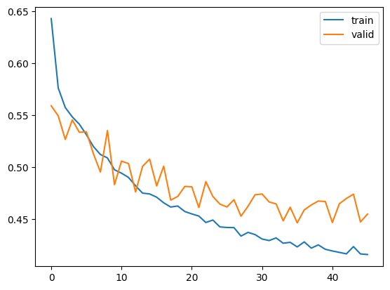

```python
# Capturing learning history per epoch
hist  = pd.DataFrame(history_balanced.history)
hist['epoch'] = history_balanced.epoch

# Plotting accuracy at different epochs
plt.plot(hist['loss'])
plt.plot(hist['val_loss'])
plt.legend(("train" , "valid") , loc =0)
```

```
Best Threshold=0.512520, G-Mean=0.828
```

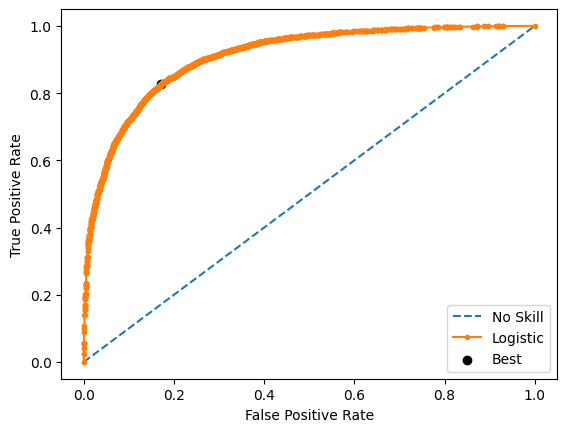

```python
# Find the optimal threshold using X_train
yhat = model_balanced.predict(x_train)

# keep probabilities for the positive outcome only
yhat = yhat[:, 0]
# calculate roc curves
fpr, tpr, thresholds = roc_curve(y_train, yhat)
# calculate the g-mean for each threshold
gmeans = np.sqrt(tpr * (1-fpr))
# locate the index of the largest g-mean
ix = np.argmax(gmeans)
print('Best Threshold=%f, G-Mean=%.3f' % (thresholds[ix], gmeans[ix]))
# plot the roc curve for the model
pyplot.plot([0,1], [0,1], linestyle='--', label='No Skill')
pyplot.plot(fpr, tpr, marker='.', label='Logistic')
pyplot.scatter(fpr[ix], tpr[ix], marker='o', color='black', label='Best')
# axis labels
pyplot.xlabel('False Positive Rate')
pyplot.ylabel('True Positive Rate')
pyplot.legend()
# show the plot
pyplot.show()
```

```python
# Obtain the predictions on x_val
y_pred_s = model_balanced.predict(x_val)
#Predicting the results using tuned threshold
y_pred_s = (y_pred_s >thresholds[ix])
y_pred_s
```

```
array([[False],
       [False],
       [False],
       ...,
       [False],
       [ True],
       [ True]])
```

```python
cr=metrics.classification_report(y_val,y_pred_s)
print(cr)
```

```
              precision    recall  f1-score   support

           0       0.92      0.82      0.86      1274
           1       0.50      0.72      0.59       326

    accuracy                           0.80      1600
   macro avg       0.71      0.77      0.73      1600
weighted avg       0.83      0.80      0.81      1600
```

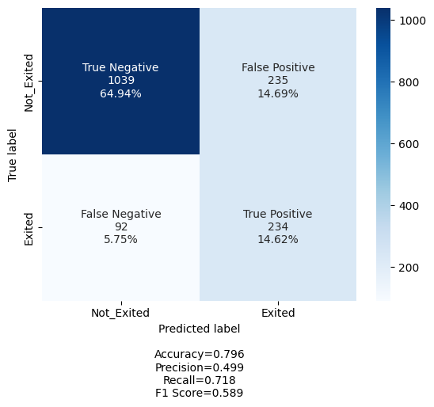

```python
#Calculating the confusion matrix
cm_s=confusion_matrix(y_val, y_pred_s)
labels = ['True Negative','False Positive','False Negative','True Positive']
categories = [ 'Not_Exited','Exited']
make_confusion_matrix(cm_s,
                      group_names=labels,
                      categories=categories,
                      cmap='Blues')
```